# #rivals - 2016 edition

# Rivals!

*one could argue that the week 1 and 12 matchup could also constitute a rivaly, but that would be dumb.

Going into the current season, team owners were asked to rank their fellow league members from 1st (biggest rival) to 12th (most benign), based on whatever past transgressions, perceived slights, imagined feuds, or other arbitrary criteria they felt was appropriate. I’ve tallied the responses, and you can read about the results below!

All of the R code used to tabulate results and generate graphics is embedded in this post, if you’re curious.

```r
options(scipen = 1, digits = 2)

# loading packages
library(dplyr)
library(tidyr)
library(tibble)
library(purrr)
library(stringr)
library(ggplot2)
library(plotly)
library(ggdendro)
library(qgraph)
library(networkD3)
library(viridis)

# SurveyMonkey apparently makes you pay to export responses in any sort of
# usable format, so I had to enter everything manually...
choices <- c("James", "Brad", "Kevin", "Shep", "Drew", "Tony", "Milf",
             "Keith", "Matt", "Toby", "Ross", "Billy")
survey_results <- list(
  Tony = list(James = 1, Brad = 3, Kevin = 6, Shep = 10, Drew = 11, Tony = 12,
              Milf = 8, Keith = 7, Matt = 2, Toby = 9, Ross = 5, Billy = 4),
  Billy = list(James = 9, Brad = 6, Kevin = 4, Shep = 10, Drew = 8, Tony = 5,
               Milf = 7, Keith = 3, Matt = 2, Toby = 12, Ross = 1, Billy = 11),
  Matt = list(James = 9, Brad = 5, Kevin = 3, Shep = 10, Drew = 8, Tony = 4,
               Milf = 11, Keith = 12, Matt = 1, Toby = 7, Ross = 6, Billy = 2),
  Milf = list(James = 10, Brad = 4, Kevin = 5, Shep = 9, Drew = 11, Tony = 7,
               Milf = 12, Keith = 3, Matt = 6, Toby = 8, Ross = 1, Billy = 2),
  Toby = list(James = 3, Brad = 1, Kevin = 11, Shep = 5, Drew = 2, Tony = 9,
               Milf = 10, Keith = 8, Matt = 7, Toby = 12, Ross = 6, Billy = 4),
  James = list(James = 12, Brad = 4, Kevin = 3, Shep = 2, Drew = 7, Tony = 1,
               Milf = 9, Keith = 6, Matt = 8, Toby = 5, Ross = 11, Billy = 10),
  Brad = list(James = 3, Brad = 12, Kevin = 6, Shep = 10, Drew = 1, Tony = 2,
               Milf = 9, Keith = 7, Matt = 5, Toby = 11, Ross = 4, Billy = 8),
  Ross = list(James = 9, Brad = 7, Kevin = 5, Shep = 12, Drew = 11, Tony = 6,
               Milf = 3, Keith = 8, Matt = 4, Toby = 10, Ross = 1, Billy = 2),
  Keith = list(James = 9, Brad = 3, Kevin = 1, Shep = 4, Drew = NA, Tony = 8,
               Milf = 7, Keith = NA, Matt = 2, Toby = 6, Ross = 5, Billy = 10),
  Shep = list(James = 8, Brad = 3, Kevin = 6, Shep = 1, Drew = NA, Tony = 10,
               Milf = 9, Keith = 2, Matt = 11, Toby = 5, Ross = 12, Billy = 4),
  Drew = list(James = 7, Brad = 2, Kevin = 4, Shep = 10, Drew = 1, Tony = 3,
               Milf = 12, Keith = 11, Matt = 8, Toby = 6, Ross = 9, Billy = 5),
  Kevin = list(James = 7, Brad = 6, Kevin = 12, Shep = 8, Drew = 9, Tony = 3,
               Milf = 4, Keith = 1, Matt = 2, Toby = 5, Ross = 10, Billy = 11)
)

# some additionally formatting to get the data in a workable structure
survey_df <- map2(survey_results, names(survey_results), function(x, y) {
  as_tibble(x) %>%
    gather(rival, rank) %>%
    mutate(responder = y)
  }) %>%
  bind_rows()
```

## Who do we hate most? (spoiler: it’s Brad)

The first thing I can do is to simply tally up the rankings for each person. I’ll assign a score to each owner, based on the average ranks given by all other owners. A higher score = more people ranked you towards the top of the rival list; a lower score = people generally think you’re irrelevant. Scores can theoretically range from 0 to 100 (cause maths).

```r
# function to rescale ranks
norm_0to1 <- function(x) {
  (x - min(x, na.rm = TRUE)) / (max(x, na.rm = TRUE) - min(x, na.rm = TRUE))
}

# get summary stats per rival
summary_df <- survey_df %>%
  mutate(norm_rank = 1 - norm_0to1(rank)) %>%
  group_by(rival) %>%
  summarise(mean_rank = mean(rank, na.rm = TRUE),
            rivaltude = mean(norm_rank, na.rm = TRUE) * 100)

# create ggplot barplot object
p1 <- summary_df %>%
  ggplot(aes(x = rival, y = rivaltude)) +
  geom_bar(stat = "identity", fill = "slategray", alpha = 0.8) +
  scale_fill_viridis() +
  xlab("") +
  ylab("Overall Rivaltude") +
  theme_minimal()

# convert to plotly
ggplotly(p1) %>%
  plotly::layout(font = list(family = "Open Sans"))
```

[interactive chart not shown]

While Matt was a close second, Brad is the winner (?) in terms of overall “rivaltude” — his score of **66.67** corresponds to an average assigned rank of **4.67** out of 12. This should not be a surprise to anyone. Brad’s pretty much the worst… In contrast, Milf’s score of **32.58** corresponds to an average ranking of **8.42**. Most of the league either really likes Milf, or doesn’t feel threatened by him whatsoever.

**NOTE:** These results are slightly biased, because several people decided to be clever and rank themselves as their biggest rival. For the sake of this particular graph though, I’m not too worried about it — if you think you’re your own worst enemy, I don’t see any reason why that vote shouldn’t count.

**OTHER NOTE:** Neither Keith nor Shep provided a response for Drew. These **`NA`s** might have been intended as the lowest possible rank (i.e., no rivalry whatsoever), which would have lowered Drew’s overall score a bit. However, I’m not going to adjust things just because people don’t know how to use a survey.

## Quantifying enmnity

Figuring out who we all dislike (on average) is interesting, but the real question is who dislikes *each other* most. Each potential rival (i.e., one of the 12 possible survey choices) nominally received a ranking from each of the other 11 owners. In turn, each rival also gave a ranking to each of the other owners. By pairing owners up and looking at their recipricol rankings, we can start to see which couples really belong together.

To make my life simpler, I assigned a rival score of **0** for every owner with himself — even for those people who ranked themselves first. I also replaced missing ranks with 12s.

If you’ve ever looked at a heatmap before, I’ve taken advantage of the convenient anagram and dubbed this graph the “HateMap”. Brighter colors mean MOAR RIVALNESS.

```r
# calculate recipricol rival scores
rival_df <- survey_df %>%
  inner_join(survey_df, by = c("responder" = "rival")) %>%
  filter(rival == responder.y) %>%
  select(-responder.y) %>%
  rename(rank_received = rank.x, rank_given = rank.y) %>%
  replace_na(list(rank_received = 12, rank_given = 12)) %>%
  mutate(norm_rank_received = 1 - norm_0to1(rank_received),
         norm_rank_given = 1 - norm_0to1(rank_given),
         rival_score = ((norm_rank_received + norm_rank_given) / 2) * 100,
         rival_score = ifelse(rival == responder, 0, rival_score))


# create ggplot heatmap object
p2 <- rival_df %>%
  filter(rival <= responder) %>%
  ggplot(aes(x = rival, y = responder)) +
  geom_tile(aes(fill = rival_score)) +
  scale_fill_viridis("Rival Score") +
  xlab("") +
  ylab("") +
  theme_minimal() +
  ggtitle('The HateMap')

ggplotly(p2) %>%
  plotly::layout(font = list(family = "Open Sans"))
```

[interactive chart not shown]

Some obvious matchups jump out here: Tony-James and Keith-Kevin both ended up with scores of 100, while Ross-Billy and Brad-Drew were pretty close. Still, relying on visual inspection of a bunch of numbers and colors to figure things out is for chumps. Let’s try more science!

## Not a clusterf!#@, just clusters

Getting a little technical here, but the rival scores I calculated above are basically “similarity” measures, indicating how closely you and another owner align in terms of potential for rivalry. Taking the inverse of these similarity measures gives us pairwise *distances*, which is the input for most data clustering algorithms. In this case, I’ll just use a pretty simple technique called hierarchical clustering to automatically group owners.

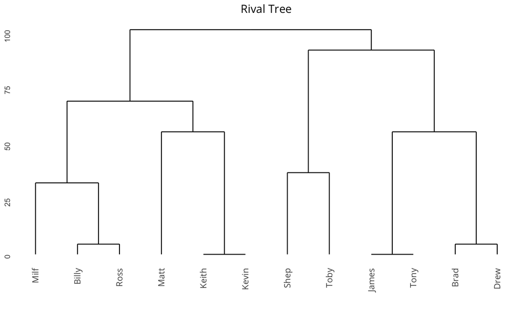

```r
# create distance matrix
rival_mat <- rival_df %>%
  filter(rival <= responder) %>%
  select(rival, responder, rival_score) %>%
  bind_rows(rival_df %>%
              filter(rival < responder) %>%
              select(rival = responder, responder = rival, rival_score)) %>%
  spread(responder, rival_score) %>%
  select(-rival) %>%
  as.matrix()

dimnames(rival_mat)[[1]] <- dimnames(rival_mat)[[2]]

# compute hierarchical clusters
rival_clust <- as.dist(100 - rival_mat) %>%
  hclust()

# plot dendrogram
rival_clust %>%
  ggdendrogram() +
  ggtitle("Rival Tree") +
  theme(axis.text.x = element_text(family = "Open Sans", size = 10),
        plot.title = element_text(family = "Open Sans"))
```

Again, the more obvious matchups shake out pretty easily. However, now I can also get a better sense of what the “next best” set of rivalries might be. Whlie the Shep-Toby matchup is admittedly less strong and a little surprising, it turns out that they’re the best fit for each other (especially because Keith is already taken…). Interestingly, both Matt and Milf are each grouped more closely to *pairs* of teams than they are to each other or any other individual team. This is again likely because what might have been reasonably strong matchups for each of them (e.g., Milf-Ross or Matt-Kevin) weren’t quite as strong as the top pairings. Matt and Milf’s rival score is actually only **31.82**, which is kinda disappointing.

```r
# extract rival pairs from clustering output
rival_pairs <- cutree(rival_clust, 6, 50) %>%
  as.data.frame() %>%
  rownames_to_column("owner1") %>%
  rename_("pair" = ".") %>%
  mutate(pair = ifelse(owner1 == "Milf", 5, pair)) %>%
  group_by(pair) %>%
  mutate(owner2 = list(owner1)) %>%
  ungroup() %>%
  unnest(owner2) %>%
  filter(owner1 != owner2) %>%
  select(-pair) %>%
  rename(rival = owner1, responder = owner2)

# get stats for rival pairs
rival_stats <- left_join(rival_pairs, rival_df) %>%
  filter(rival <= responder) %>%
  summarise(mean_score = mean(rival_score),
            min_score = min(rival_score))
```

## Maybe a bit of a clusterf!#@…

Doing a quick check, I can see that the average rival score taking the 6 pairs in this configuration is **81.06**. Not terrible, but not awesome. (As an aside, hierarchical clustering algorithms are not designed to produce any sort of “globally optimal” groupings — but I’ll save that discussion for anyone that’s more curious). To see what the clustering looks at with a little bit of tweaking, I downweighted any high, but not perfect rival scores: that is, for the Brad-Drew and Ross-Billy matchups, I adjusted scores from ~95 down to 90 and recomputed the clustering tree.

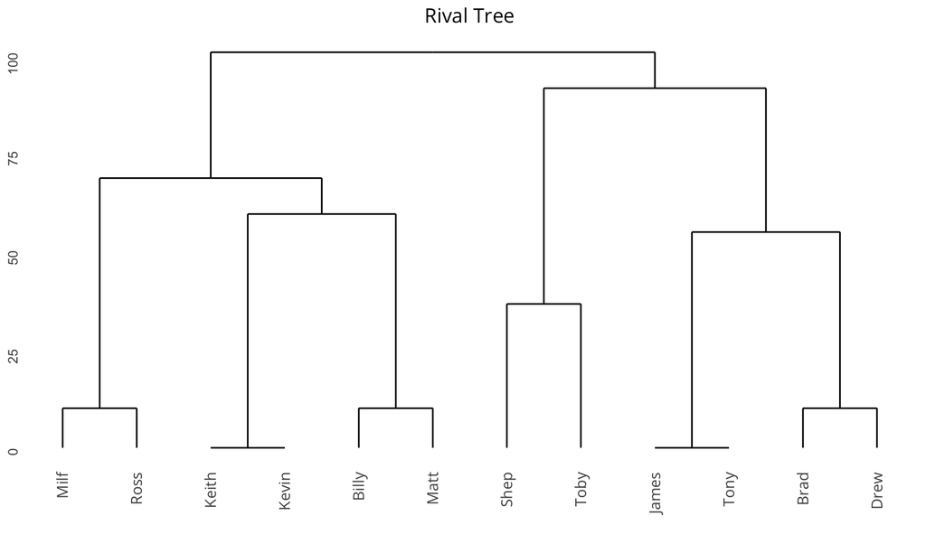

```r
# create modified distance matrix
rival_mat_new <- rival_mat
rival_mat_new[rival_mat_new > 90 & rival_mat_new < 100] = 90

# compute hierarchical clusters
rival_clust_new <- as.dist(100 - rival_mat_new) %>%
  hclust()

# plot dendrogram
rival_clust_new %>%
  ggdendrogram() +
  ggtitle("Rival Tree") +
  theme(axis.text.x = element_text(family = "Open Sans", size = 10),
        plot.title = element_text(family = "Open Sans"))
```

```r
# extract rival pairs from clustering output
rival_pairs_new <- cutree(rival_clust_new, 6) %>%
  as.data.frame() %>%
  rownames_to_column("owner1") %>%
  rename_("pair" = ".") %>%
  group_by(pair) %>%
  mutate(owner2 = list(owner1)) %>%
  ungroup() %>%
  unnest(owner2) %>%
  filter(owner1 != owner2) %>%
  select(-pair) %>%
  rename(rival = owner1, responder = owner2)

# get stats for rival pairs
rival_stats_new <- left_join(rival_pairs_new, rival_df) %>%
  filter(rival <= responder) %>%
  summarise(mean_score = mean(rival_score),
            min_score = min(rival_score))
```

By loosening up the “attraction” between Billy and Ross a bit, we end up with two new pairings: Milf-Ross and Billy-Matt; everything else stayed the same. With this setup, the minimum rival score is now **63.64** and the average is up to **90.15**. The dropoffs in individual scores for each of the new matchups is pretty minimal, and I think both could be entertaining. The Shep-Toby matchup is still a bit weak, but maybe it can be the start of something great?

## Networks — ’cause why not?

The graphic below doesn’t really add any information, but I thought it would be fun to make anyway. The diameter of each node is proportional to the “rivaltude” score from the first graph above. The length of each connecting edge is (nominally) inversely proportional to rival score: closer proximity in the network indicates stronger rivals. Due to the way the network gets drawn, the distance between nodes isn’t always a perfect translation of rival score — I’ve also set the width of each edge to scale with rival score, so thicker lines also means stronger rivals. Have some fun playing around with the diagram.

```r
# use qgraph to build network
q <- qgraph(rival_mat, layout = 'spring', DoNotPlot = TRUE, vsize = 10)

# create & format links/edges objects for graphing
links <- q$Edgelist %>%
  as.data.frame() %>%
  select(-directed, -bidirectional) %>%
  mutate(from = from - 1,
         to = to - 1)

nodes <- data_frame(rival = names(q$graphAttributes$Nodes$labels)) %>%
  mutate(group = 1) %>%
  left_join(summary_df,
            by = c("rival" = "rival")) %>%
  rename(score = rivaltude) %>%
  mutate(score = score - mean(score),
         score = score - min(score) + 1)

# plot network with networkD3 function
forceNetwork(links, nodes, Source = "from", Target = "to", Value = "weight",
             NodeID = "rival", Nodesize = "score", Group = "score",
             linkDistance = JS("function(d){return (101 - d.value) * 8}"),
             linkWidth = JS("function(d){return Math.pow((d.value / 20), 2)}"),
             linkColour = "#50A6C2",
             radiusCalculation = JS("d.nodesize + 10"),
             fontSize = 12, fontFamily = "Open Sans",
             opacity = 0.6, opacityNoHover = 1,
             charge = 0)
```

[interactive chart not shown]

## Conclusions

Your 2016 rivalries, based on the data (and some minor adjustments) are as follows:

- **Kevin-Keith**
- **James-Tony**
- **Brad-Drew**
- **Billy-Matt**
- **Milf-Ross**
- **Shep-Toby**

Now I just need to figure out how to build a schedule around all of this. That might be an interesting topic for a follow-up post…

Also, this was a massive time sink that didn’t help me prepare for the actual draft or season whatsoever. Crap.